# Monte_Carlo_Integration_Examples_and_Exercise

## Monte Carlo Integration

### Mathematical and Numerical Methods - CDSC 603

#### Ababa University College of Natural Competational Science

#### Assignment I

**Submitted to:** Hailemichael Kebede (Phd) </br> **Prepared by:** Mekonnen Assefa - GSR/5041/13

#### Example 1

We want to estiamte the following integral:  
$\int_0^1 e^x dx$  
The minimum value of the function is 1 at $x=0$ and $e$ at $x=1$.

```python
#Python Import
import os
import sys
import glob
import matplotlib.pyplot as plt
import numpy as np
import pandas as pd
%matplotlib inline
%precision 4
plt.style.use('ggplot')
```

```python
from __future__ import division
import scipy.stats as stats
import seaborn as sns
```

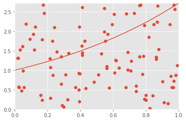

```python
#Program starts here

x = np.linspace(0, 1, 100)
plt.plot(x, np.exp(x));
pts = np.random.uniform(0,1,(100, 2))
pts[:, 1] *= np.e
plt.scatter(pts[:, 0], pts[:, 1])
plt.xlim([0,1])
plt.ylim([0, np.e]);
```

```python
# Check analytic solution

from sympy import symbols, integrate, exp

x = symbols('x')
expr = integrate(exp(x), (x,0,1))
expr.evalf()
```

$\displaystyle 1.71828182845905$

```python
# Using numerical quadrature
# You may recall elementary versions such as the
# trapezoidal and Simpson's rules
# Note that nuerical quadrature needs $n^p$ grid points
# in $p$ dimensions to maintain the same accuracy
# This is known as the curse of dimensionality and explains
# why quadrature is not used for high-dimensional integration

from scipy import integrate
integrate.quad(exp, 0, 1)
```

```
(1.7183, 0.0000)
```

```python
# Monte Carlo approximation

for n in 10**np.array([1,2,3,4,5,6,7,8]):
    pts = np.random.uniform(0, 1, (n, 2))
    pts[:, 1] *= np.e
    count = np.sum(pts[:, 1] < np.exp(pts[:, 0]))
    volume = np.e * 1 # volume of region
    sol = (volume * count)/n
    print ('%10d %.6f' % (n, sol))
```

```
        10 2.174625
       100 1.603786
      1000 1.647279
     10000 1.714964
    100000 1.712327
   1000000 1.719457
  10000000 1.717932
 100000000 1.718166
```

### Exercise 1:

Resolve the integral using the analytical and monte carlo method

$\int_1^5 x^2 dx$

### Exercise 2:

Resolve the integral using the analytical and monte carlo method.

$\int_3^2 x^2 + 4 x sin(x)$.

### Example 2: Montioring variance

We are often interested in knowning how many iterations it takes for Monte Carlo integration to “converge”. To do this, we would like some estimate of the variance, and it is useful to inspect such plots. One simple way to get confidence intervals for the plot of Monte Carlo estimate against number of interations is simply to do many such simulations.

**For the example**, we willl try to etsimate the function

```python
def f(x):
    return x * np.cos(71*x) + np.sin(13*x)
```

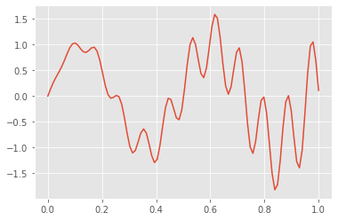

```python
x = np.linspace(0, 1, 100)
plt.plot(x, f(x));
```

**Exact solution¶**

```python
from sympy import sin, cos, symbols, integrate

x = symbols('x')
integrate(x * cos(71*x) + sin(13*x), (x, 0,1)).evalf(6)
```

$\displaystyle 0.0202549$

**Using multiple independent sequences**

```python
n = 100
reps = 1000
```

```python
x = f(np.random.random((n, reps)))
y = 1/np.arange(1, n+1)[:, None] * np.cumsum(x, axis=0)
upper, lower = np.percentile(y, [2.5, 97.5], axis=1)
```

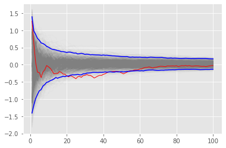

```python
plt.plot(np.arange(1, n+1), y, c='grey', alpha=0.02)
plt.plot(np.arange(1, n+1), y[:, 0], c='red', linewidth=1);
plt.plot(np.arange(1, n+1), upper, 'b', np.arange(1, n+1), lower, 'b');
```

**Using bootstrap**

```python
xb = np.random.choice(x[:,0], (n, reps), replace=True)
yb = 1/np.arange(1, n+1)[:, None] * np.cumsum(xb, axis=0)
upper, lower = np.percentile(yb, [2.5, 97.5], axis=1)
```

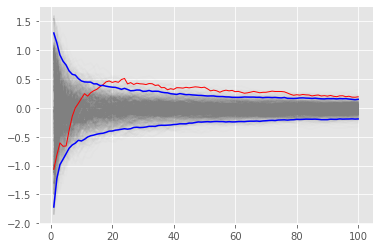

```python
plt.plot(np.arange(1, n+1)[:, None], yb, c='grey', alpha=0.02)
plt.plot(np.arange(1, n+1), yb[:, 0], c='red', linewidth=1)
plt.plot(np.arange(1, n+1), upper, 'b', np.arange(1, n+1), lower, 'b');
```

### Example 3 : Variance reduction by change of variables

The Cauchy distribution is given by

$f(x) = \frac{1}{\pi(1+x^2)}$ , $-\infty \lt x \lt \infty$

Suppose we want to integrate the tail probability $P(X\gt3)$ using Monte Carlo

```python
h_true = 1 - stats.cauchy().cdf(3)
h_true
```

```
0.10241638234956674
```

**Direct Monte Carlo integration is inefficient since only 10% of the samples give inforrmation about the tail**

```python
n = 100

x = stats.cauchy().rvs(n)
h_mc = 1.0/n * np.sum(x > 3)
h_mc, np.abs(h_mc - h_true)/h_true
```

```
(0.07, 0.3165155964884935)
```

We are trying to estimate the quantity

$\int_3^\infty \frac{1}{\pi(1+x^2)} dx$

Using the substitution $y=3/x$ (and a little algebra), we get

$\int_0^1 \frac{3}{\pi(9+y^2)} dx$

Hence, a much more efficient MC estimator is

$\frac{1}{n} \sum_i=1^n \frac{3}{\pi(9+(y_i)^2)} $

where $y_i ∼ \mu(0,1)$

```python
y = stats.uniform().rvs(n)
h_cv = 1.0/n * np.sum(3.0/(np.pi * (9 + y**2)))
h_cv, np.abs(h_cv - h_true)/h_true
```

```
(0.10217543018573201, 0.002352672085334066)
```

### Example 4: Importance sampling

Suppose we want to estimate the tail probability of $N(0,1)$ for $P(X>5)$. Regular MC integration using samples from $N(0,1)$ is hopeless since nearly all samples will be rejected. However, we can use the exponential density truncated at 5 as the importance function and use importance sampling.

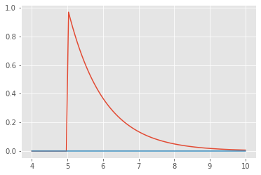

```python
x = np.linspace(4, 10, 100)
plt.plot(x, stats.expon(5).pdf(x))
plt.plot(x, stats.norm().pdf(x));
```

**Expected answer**

We expect about 3 draws out of 10,000,000 from $N(0,1)$ to have a value greater than 5. Hence simply sampling from $N(0,1)$ is hopelessly inefficient for Monte Carlo integration

```python
%precision 10
```

```python
h_true =1 - stats.norm().cdf(5)
h_true
```

```
2.866515719235352e-07
```

**Using direct Monte Carlo integration**

```python
n = 10000
y = stats.norm().rvs(n)
h_mc = 1.0/n * np.sum(y > 5)
# estimate and relative error
h_mc, np.abs(h_mc - h_true)/h_true
```

```
(0.0, 1.0)
```

**Using importance sampling**

```python
n = 10000
y = stats.expon(loc=5).rvs(n)
h_is = 1.0/n * np.sum(stats.norm().pdf(y)/stats.expon(loc=5).pdf(y))
# estimate and relative error
h_is, np.abs(h_is- h_true)/h_true
```

```
(2.8767486743032567e-07, 0.0035698234617162756)
```

### Example 5: Estimating the value of pi

Consider the largest circle which can be fit in the square ranging on $\mathbb{R}^2$ over $[-1, 1]^2$. The circle has a radius 1, and area $\pi$. The square has an area of $2^2$ = 4. The ratio between their areas is thus $\pi/4$.

We can approximate the value of π using a Monte Carlo method using the following procedure:

- draw the square over $[-1,1]^2$ then draw the largest circle that fits inside the square
- randomly scatter a large number $N$ of grains of rice over the square
- count how many grains fell inside the circle
- the count divided by $N$ and multiplied by 4 is an approximation of $\pi$

We can simulate this procedure in NumPy by drawing random numbers from a uniform distribution between -1 and 1 to represent the $x$ and $y$ positions of our grains of rice, and checking whether the point is within the circle using [Pythagoras’ theorem](https://en.wikipedia.org/wiki/Pythagorean_theorem). This procedure is an adaptation of what's called [Buffon's needle problem](https://en.wikipedia.org/wiki/Buffon%27s_needle_problem), after the 18th century French mathematician the Count of Button. It belongs to an topic called geometric probability.

```python
import numpy
import matplotlib.pyplot as plt
plt.style.use("bmh")
```

```python
N = 10_000
inside = []
for i in range(N):
    x = numpy.random.uniform(-1, 1)
    y = numpy.random.uniform(-1, 1)
    if numpy.sqrt(x**2 + y**2) < 1:
        inside.append((x, y))
```

We can plot the points that we have marked as being inside the circle, to check that we indeed have an approximation to a circle.

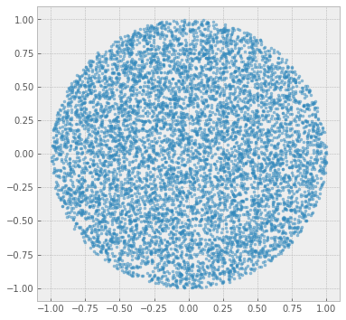

```python
plt.figure(figsize=(6, 6))
plt.scatter([x[0] for x in inside], [x[1] for x in inside], marker=".", alpha=0.5);
```

Finally, we can check our estimate of $\pi$ as the count divided by N and multiplied by 4:

```python
4 * len(inside)/float(N)
```

```
3.1244000000
```

**Speed of convergence**

Theory tells us that the convergence of a Monte Carlo procedure is related to the square root of the number of iterations. This means that the estimation error should decrease proportionally to the inverse of the square root of $N$, the number of iterations.

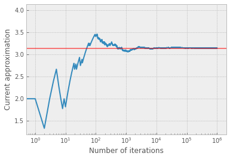

```python
N = 1_000_000
inside = 0
approximation = numpy.empty(N)
for i in range(N):
    x = numpy.random.uniform(-1, 1)
    y = numpy.random.uniform(-1, 1)
    if numpy.sqrt(x**2 + y**2) < 1:
        inside += 1
    approximation[i] = 4 * inside/float(i+1)
plt.semilogx(approximation)
plt.xlabel("Number of iterations")
plt.ylabel("Current approximation")
# plot the exact value of pi in red
plt.axhline(numpy.pi, color="r", alpha=0.5);
```

### Exercise 4:

Let’s check that the error decreases proportionally to $\frac{1}{\sqrt{N}}$.

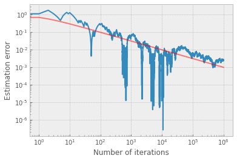

```python
plt.loglog(numpy.arange(N), numpy.abs(approximation-numpy.pi))
plt.loglog(1/numpy.sqrt(numpy.arange(N)+1), color="r", alpha=0.5)
plt.xlabel("Number of iterations")
plt.ylabel("Estimation error");
```

### Exercise 5:

Use a similar Monte Carlo procedure in dimension 3 to estimate $\pi$ (your analysis will be based on the volume of a sphere of radius 1, instead of the area of a circle of radius 1). Recall that the volume of a sphere of radius $r$ is $\frac{4}{3}\pi r^3$.

## Thank You

Mekonnen Assefa  
Date : April 2, 2021